# Data607 - Project 2: Data Transformation with Astronomical Data

Anthony Josue Roman

2024-10-06

This assignment will use the following packages:

```r
library(readr)
library(RCurl)
library(stringr)
library(dplyr)
library(tidyr)
library(tidyverse)
library(ggplot2)
library(knitr)
library(kableExtra)
```

## Introduction

Astronomy has played a key role in advancement of human civilization and to understand our universe. Exoplanets, planets not apart of our system, have been an interest of astronomers for centuries, which may indicate potential possibilities of extraterrestrial life. Gaia, which was launched earlier plays a key role in advancements in Astronomy as it is used to analyze the stars of our universe and for other Astronomy missions.

The following project will utilize three datasets I have obtained from the Sloan Digital Sky survey data and Gaia. The first dataset will be exoplanet dataset from [Sloan Digital Sky Survey](https://exoplanetarchive.ipac.caltech.edu/cgi-bin/TblView/nph-tblView?app=ExoTbls&config=PS), the second and third dataset will be from [Gaia Archive](https://gea.esac.esa.int/archive/).

## Initializing datasets

The following datasets are extracted from my [Github Page](https://github.com/spacerome/Data607_Project_2). This will convert them into data frames.

```r
rawgaia <- getURL("https://raw.githubusercontent.com/spacerome/Data607_Project_2/refs/heads/main/gaiadata.csv")

rawgaia2 <- getURL("https://raw.githubusercontent.com/spacerome/Data607_Project_2/refs/heads/main/gaiadata2.csv")

rawsds <- getURL("https://raw.githubusercontent.com/spacerome/Data607_Project_2/refs/heads/main/PS_2024.10.06_14.59.24.csv")

gaiadf <- data.frame(read.csv(text=rawgaia, sep= "\t", stringsAsFactors = FALSE, check.names = FALSE))

gaiadf2 <- data.frame(read.csv(text=rawgaia2, sep= "\t", stringsAsFactors = FALSE, check.names = FALSE))

sdsdf <- data.frame(read.csv(text=rawsds, sep= "\t", stringsAsFactors = FALSE, check.names = FALSE))
```

## Tidying the Data: Gaia Data Frames

This code block will tidy the following dataset from `gaiadf` and `gaiadf2` respectively:

```r
gaiadf_tidy <- gaiadf %>%
  pivot_longer(
    cols = -SOURCE_ID,
    names_to = c("measurement_type", "band", "replicate"),
    names_pattern = "(\\w+)_(\\w+)_(\\d)",
    values_to = "value"
  ) %>%
  filter(!is.na(value))

head(gaiadf_tidy)
```

```
## # A tibble: 6 × 5
##   SOURCE_ID measurement_type band  replicate value
##       <dbl> <chr>            <chr> <chr>     <dbl>
## 1   4.04e18 dec              bp    1         -34.4
## 2   4.04e18 dec              bp    2         -34.4
## 3   4.04e18 dec              g     1         -34.4
## 4   4.04e18 dec              g     2         -34.4
## 5   4.04e18 dec              rp    1         -34.4
## 6   4.04e18 dec              rp    2         -34.4
```

```r
gaiadf2_tidy <- gaiadf2 %>%
  pivot_longer(
    cols = -source_id,
    names_to = "attribute",
    values_to = "value"
  ) %>%
  filter(!is.na(value))

head(gaiadf2_tidy)
```

```
## # A tibble: 6 × 3
##   source_id attribute        value
##       <dbl> <chr>            <dbl>
## 1   4.19e17 ra               10.1
## 2   4.19e17 dec              56.5
## 3   4.19e17 parallax         14.1
## 4   4.19e17 phot_g_mean_mag   1.94
## 5   4.19e17 phot_bp_mean_mag  2.99
## 6   4.19e17 phot_rp_mean_mag  1.84
```

### Analysis of Data

We will analyze the data from `gaiadf_tidy` first then will analyze `gaiadf2_tidy`.

This will basically calculate the summary statistics for each measurement such as dec (declination), ra (right ascension), magnitude, parallax for each band `rp`, `bp`, and `g`. The bands are defined as `bp` is Blue Photometer, `g` is Gaia’s main photometric band, and `rp` is the Red Photometer.

```r
gaiadf_tidy %>%
  group_by(measurement_type, band) %>%
  summarize(
    mean_value = mean(as.numeric(value), na.rm = TRUE),
    sd_value = sd(as.numeric(value), na.rm = TRUE),
    min_value = min(as.numeric(value), na.rm = TRUE),
    max_value = max(as.numeric(value), na.rm = TRUE),
    count = n()
  ) %>%
  arrange(measurement_type, band)
```

```
## # A tibble: 12 × 7
## # Groups:   measurement_type [4]
##    measurement_type band  mean_value sd_value  min_value max_value count
##    <chr>            <chr>      <dbl>    <dbl>      <dbl>     <dbl> <int>
##  1 dec              bp        -66.2      2.69 -70.2          -34.4 10000
##  2 dec              g         -66.2      2.69 -70.2          -34.4 10000
##  3 dec              rp        -66.2      2.69 -70.2          -34.4 10000
##  4 magnitude        bp         19.2      2.09   7.61          22.6  9928
##  5 magnitude        g          18.5      1.99   7.28          21.1  9998
##  6 magnitude        rp         17.7      1.90   5.93          20.8  9930
##  7 parallax         bp          1.01     1.39   0.000521      61.2 10000
##  8 parallax         g           1.01     1.39   0.000521      61.2 10000
##  9 parallax         rp          1.01     1.39   0.000521      61.2 10000
## 10 ra               bp         58.1      9.89  50.7          274.  10000
## 11 ra               g          58.1      9.89  50.7          274.  10000
## 12 ra               rp         58.1      9.89  50.7          274.  10000
```

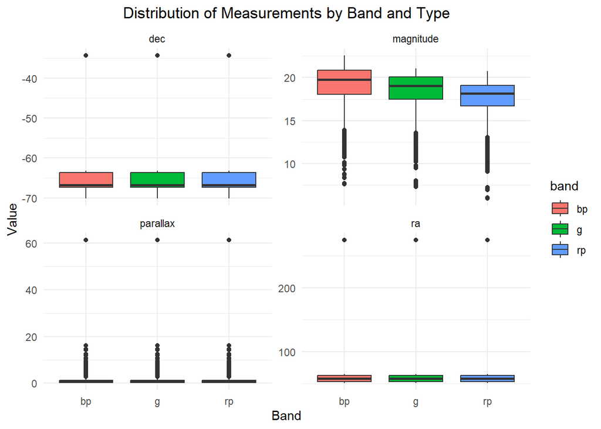

```r
ggplot(gaiadf_tidy, aes(x = band, y = as.numeric(value), fill = band)) +
  geom_boxplot() +
  facet_wrap(~ measurement_type, scales = "free_y") +
  labs(title = "Distribution of Measurements by Band and Type",
       y = "Value", x = "Band") +
  theme_minimal() +
  theme(
    plot.title = element_text(hjust = 0.5)
  )
```